```python
%matplotlib notebook
import numpy as np
from pandas import Series
from numpy import array, dot, sin, cos, pi, exp
from scipy.linalg import solve_banded
import matplotlib.pyplot as plt
from mpl_toolkits.mplot3d import Axes3D
from matplotlib import rc
np.set_printoptions(precision=4, suppress=True)
rc('font',**{'family':'sans-serif','sans-serif':['Helvetica']})
rc('text', usetex=True)
```

# Методы решения начально-краевых задач для параболических уравнений

## Постановка задачи

Рассмотрим линейное уравнение распространения тепла на прямой с заданой начальной температурой стержня и температурным режимом на его концах:

$$ \frac{\partial u}{\partial t} = a^2 \frac{\partial^2 u}{\partial x^2} + f(x, t), \text{ }x\in(0; l),\text{ }t > 0,\\ u\rvert_{t=0}=\varphi(x),\\ u\rvert_{x=0}=\mu_1(t),\text{ }u\rvert_{x=l}=\mu_2(t).$$

В нашем случае задача имеет следующий вид:

$$ \frac{\partial u}{\partial t} = \frac{1}{4\pi^2} \frac{\partial^2 u}{\partial x^2} + 3 \sin{2t}\sin{\pi x}, \text{ }x\in(0; 1),\text{ }t > 0,\\ u\rvert_{t=0}=2\sin{4\pi x} - 3 - x,\\ u\rvert_{x=0}=-3,\text{ }u\rvert_{x=l}=-4.$$

```python
l = 1
a = 1 / (2*pi)
f = lambda x, t: 3 * sin(2*t) * sin(pi*x)
phi = lambda x: 2*sin(4*pi*x) - 3 - x
mu1 = lambda t: -3
mu2 = lambda t: -4
```

## Точное решение методом Фурье

Первое, что стоит сделать $-$ свести задачу с неоднородными краевыми условиями к задаче с однородными. Делается это заменой

$$ u(x, t) = v(x, t) + w(x, t), $$

где $v=v(x, t)$ $-$ новая неизвестная функция, а $w(x, t) = \mu_1(t) + \frac{x}{l}\left(\mu_2(t)-\mu_1(t)\right)$.

Итак, пусть перед нами стоит исходная задача, но теперь уже отосительно функции $v(x, t)$ и краевые условия однородны. В общем виде решение такой задачи с помощью метода Фурье представляется так:

$$ v(x, t)= \sum\limits_{n=1}^{\infty}\varphi_n e^{-(\frac{\pi n}{l})^2 a^2 t} \sin{\frac{\pi n}{l}x} + \sum\limits_{n=1}^{\infty}\left[ \int\limits_0^t {f_n(\tau)e^{-(\frac{\pi n}{l})^2 a^2 (t-\tau)}d\tau} \right]\sin{\frac{\pi n}{l}x},$$

где $$f_n(t)=\frac{2}{l}\int\limits_0^l f(x, t)\sin{\frac{\pi n}{l}x}dx,\text{ } \varphi_n=\frac{2}{l}\int\limits_0^l \varphi(x)\sin{\frac{\pi n}{l}x}dx.$$

Пользоваться этой формулой, однако, крайне неудобно (хотя в нашем случае, когда заданные функции $f$ и $\varphi$ содержат в себе синусоиды, многие элементы $f_n$ и $\varphi_n$ обнулятся), поэтому решим нашу конкретную задачу поэтапно.

Прежде всего, сделаем замену $u = v + w$, где $v$ будет нашей новой неизвестной функцией, а $w=-3-x$. Подставим эту замену в нашу задачу и перейдём к следующей:

$$ \frac{\partial v}{\partial t} = \frac{1}{4\pi^2} \frac{\partial^2 v}{\partial x^2} + 3 \sin{2t}\sin{\pi x}, \text{ }x\in(0; 1),\text{ }t > 0,\\ v\rvert_{t=0}=2\sin{4\pi x},\\ v\rvert_{x=0}=0,\text{ }v\rvert_{x=l}=0.$$

Решение этой задачи, согласно методу Фурье, будем искать в виде ряда Фурье по собственным функциям задачи Штурма-Лиувиля (с нашими начальными условиями удобно выбрать систему $\{\sin{\frac{\pi n x}{l}}\}_{n=1}^{\infty}$):

$$ v(x, t) = \sum\limits_{n=1}^{\infty} A_n(t)\sin{\pi n x}.$$

Неопределённые функции $A_n$ выберем так, чтобы функция $v$ удовлетворяла

а) начальным условиям: $v(x, 0)\equiv \sum\limits_{n=1}^{\infty} A_n(0)\sin{\pi n x}=2\sin{4\pi x} \Rightarrow A_4(0)=2, \forall n\in\mathbb{N}: n\neq4 \text{ }A_n(0)=0$;

б) дифференциальному уравнению. Найдём сперва производные, участвующие в уравнении.

$$ \frac{\partial v}{\partial t}=\sum\limits_{n=1}^{\infty} A_n'(t)\sin{\pi n x}, \frac{\partial^2 v}{\partial t^2}=\sum\limits_{n=1}^{\infty} A_n(t)(-\pi^2 n^2)\sin{\pi n x}.$$

Подставим теперь их в уравнение и получим

$$ \sum\limits_{n=1}^{\infty} \left[A_n'(t) + \frac{n^2}{4}A_n(t)\right]\sin{\pi n x}=3\sin{2t}\sin{\pi x}\Rightarrow$$$$ A_1'+\frac{A_1}{4}=3\sin{2t},\text{ }\forall n>1\text{ }A_n'+\frac{n^2}{4}A_n = 0.$$

Дополнив эти дифференциальные уравнения начальными условиями для $A_n$, которые мы нашли выше, и решив эти задачи Коши, получим следующие результаты:

$$ A_1(t)=\frac{1}{65}\left(96e^{-\frac{t}{4}}+12\sin{2t}-96\cos{2t}\right), A_4(t)=2e^{-4t}, \forall n \notin\{1, 4\}\text{ } A_n(t)\equiv0.$$

Подставляя в ряд выше, получим $$v(x, t)=\frac{1}{65}\left(96e^{-\frac{t}{4}}+12\sin{2t}-96\cos{2t}\right)\sin{\pi x} + 2e^{-4t}\sin{4\pi x},$$ и, окончательно, $$u(x, t)=\frac{1}{65}\left(96e^{-\frac{t}{4}}+12\sin{2t}-96\cos{2t}\right)\sin{\pi x} + 2e^{-4t}\sin{4\pi x}-3-x.$$

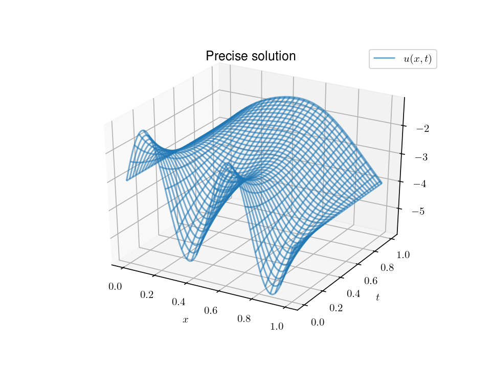

```python
u_true = lambda x, t: 1/65*(96*exp(-t/4)+12*sin(2*t)-96*cos(2*t))*sin(pi*x) + 2*exp(-4*t)*sin(4*pi*x) - 3 - x
x_dense = np.linspace(0, l, 101)
t_dense = np.linspace(0, 1, 101)
xx_dense, tt_dense = np.meshgrid(x_dense, t_dense)

fig1 = plt.figure()
ax1 = fig1.add_subplot(111, projection='3d')
ax1.plot_wireframe(xx_dense, tt_dense, u_true(xx_dense, tt_dense), alpha=0.6, label='$u(x, t)$')
ax1.set_xlabel('$x$'); ax1.set_ylabel('$t$')
ax1.set_title("Precise solution")
ax1.legend();
```

```python
def plot_solution(uu, xx, tt, u_true, method_name):
    global xx_dense, tt_dense
    h = xx[0, 1] - xx[0, 0]
    tau = tt[1, 0] - tt[0, 0]
    fig = plt.figure(figsize=(9, 4))
    ax1 = fig.add_subplot(121, projection='3d')
    ax1.plot_wireframe(xx_dense, tt_dense, u_true(xx_dense, tt_dense), alpha=0.6, label='$u(x, t)$')
    ax1.plot_wireframe(xx, tt, uu, alpha=0.75, color='r',
                       label='$\hat{u}(x, t), h=%.2f, \\tau=%.2f$' % (h, tau))
    ax1.scatter(xx, tt, uu, alpha=0.75, s=10, c='r')
    ax1.set_title('Solution with "%s" method' % method_name)

    ax2 = fig.add_subplot(122, projection='3d')
    ax2.plot_wireframe(xx, tt, np.abs(uu - u_true(xx, tt)),
                       label='$|\hat{u} - u|, h=%.2f, \\tau=%.2f$' % (h, tau))
    ax2.set_title('Error of solution')

    for ax in fig.get_axes():
        ax.set_xlabel('$x$'); ax.set_ylabel('$t$')
        ax.legend(loc=3);

    fig.tight_layout()
    return fig
```

## Сеточные методы

### Идеи и основные понятия

Как и для эллиптических уравнений, сеточные методы заключаются в дискретизации области определения, в которой ищется решение, путём введения конечной сетки по всем переменным, а также замены дифференциальных выражений, присутствующих в уравнении, определёнными разностными схемами относительно значений искомой функции в узлах сетки.

Будем рассматривать конечную прямоугольную область. По иксу (пространственной переменной) всё уже хорошо. Временная переменная же может принимать любые положительные значения, что нас не очень устраивает, поэтому мы ограничиваем их каким-то моментом времени $T$ (есть способы работать и с бесконечно большими моментами времени, но не будем об этом). В итоге получили прямоугольную область $\overline{\Omega}=[0; l]\times[0; T]$.

Сеткой $\overline{\Omega}_{h}^{\tau}$ будем называть точки пересечения вертикальных (пространственных, $x=x_i=ih$, где $h=l / n$) и горизонтальных (временных, $t=t_k = k\tau$, где $\tau = T/m$) прямых. Узлы, лежащие на одной вертикальной прямой $t=t_k$ называются $k$-м временным слоем.

Будем использовать обозначение $u_i^k := u(x_i, t_k)$, $\mu_j(t_k):=\mu_j^k$, $\varphi_j(x_i):=\varphi_i$.

Величины $h$ и $\tau$ называются шагами сетки. Правильный выбор их значений достаточно важен для хорошей работы метода. От их величин или даже соотношения может зависить сходимость и устойчивость методов. Вообще, в отличии от стационарных эллиптических уравнений, мы будем искать порядок аппроксимации уравнения разностной схемой как величину, одновременно зависящую и от шага по пространственной переменной, и от шага по временной, в виде $O(h^p + \tau^q), h\to0, \tau\to0$.

Величина $\gamma=\frac{a^2\tau}{h^2}$ называется числом Курранта и обычно с ней связаны условия устойчивости схемы.

```python
h, tau, T = 0.1, 0.1, 1
gamma = a**2 * tau / h**2
print('gamma = %.4f' %gamma)
```

```
gamma = 0.2533
```

```python
# подготовим все нужные структурные элементы
n, m = int(1/h),  int(1/tau)
x = np.linspace(0, 1, n+1)
t = np.linspace(0, 1, m+1)
xx, tt = np.meshgrid(x, t)
ff = f(xx, tt)
uu = np.zeros_like(xx)
```

Заполним значения функции $u$ на первом временном слое сетки:

$$u_i^0 = 2\sin{4\pi x_i} - 3 - x_i, i=0,1,..., n.$$

```python
# первый временной слой задаём из начальных условий
uu[0] = phi(x)
# на краях отрезка зададим температурный режим
uu[:,  0] = mu1(t)
uu[:, -1] = mu2(t)
```

### Аппроксимация уравнения с помощью разностных схем

#### A. Явная схема

Шаблон:

Производные аппроксимируются достаточно естественными разностными аналогами:

$$ \begin{align} &\frac{\partial u}{\partial t}\Bigg\rvert_{(x_i, t_k)}=\frac{u_i^{k+1}-u_i^k}{\tau}+O(\tau),\\ &\frac{\partial^2 x}{\partial x^2}\Bigg\rvert_{(x_i ,t_k)}=\frac{u_{i-1}^k - 2u_i^k + u_{i+1}^k}{h^2}+O(h^2). \end{align}$$

Подставляя в исходное уравнение, можем получить такое выражение для значения функции на узлах следующего слоя через значения на текущем слое:

$$u_0^{k+1} = \mu_1^{k+1},\\ u_i^{k+1} = \gamma u_{i-1}^k + (1-2\gamma)u_i^k + \gamma u_{i+1}^k + \tau f_i^k,\text{ }i\in\{1, 2, ..., n-1\},\\ u_n^{k+1} = \mu_2^{k+1}.$$

Эту формулу мы постепенно применяем на всех слоях, пока не построим значения функции во всех узлах сетки. Помним, что нулевой слой нам уже задан, как и граничные условия.

Схема имеет порядок сходимости $O(h^2 + \tau)$ и является условно устойчивой (устойчива при $\gamma=\frac{a^2\tau}{h^2}\leq\frac{1}{2}$).

В нашем случае число Курранта равно $\frac{5}{2\pi^2}=0,253<0,5$, поэтому схема устойчива. Рассчётные формулы для получения значений функции на следующем временном слое:

$$u_0^{k+1} = -3,\\ u_i^{k+1} = \frac{5}{2\pi^2} u_{i-1}^k + (1-\frac{5}{\pi^2})u_i^k + \frac{5}{2\pi^2} u_{i+1}^k + 0,3 \sin{2t_k}\sin{\pi x_i},\text{ }i\in\{1, 2, ..., 9\},\\ u_{10}^{k+1} = -4.$$

```python
uu_expl = uu.copy()

for k in range(m):
    uk, fk = uu_expl[k], ff[k]
    uu_expl[k+1, 1:-1] = gamma*uk[:-2] + (1-2*gamma)*uk[1:-1] + gamma*uk[2:] + tau*fk[1:-1]
```

Максимальная погрешность аппроксимации на каждом временном слое:

```python
Series(np.max(np.abs(uu_expl - u_true(xx, tt)), axis=1), index=t)
```

```
0.0    8.881784e-16
0.1    6.695860e-02
0.2    1.052363e-01
0.3    1.272726e-01
0.4    1.395470e-01
0.5    1.452038e-01
0.6    1.456127e-01
0.7    1.412834e-01
0.8    1.323915e-01
0.9    1.190691e-01
1.0    1.015555e-01
dtype: float64
```

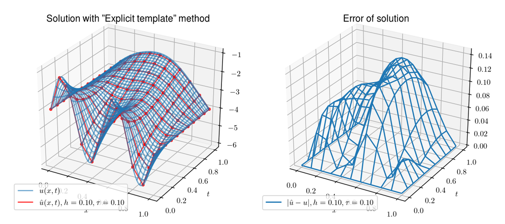

```python
fig2 = plot_solution(uu_expl, xx, tt, u_true, 'Explicit template')
```

#### B. Неявная схема

Шаблон:

Аппроксимация производных:

$$ \begin{align} &\frac{\partial u}{\partial t}\Bigg\rvert_{(x_i, t_k)}=\frac{u_i^{k+1}-u_i^k}{\tau}+O(\tau),\\ &\frac{\partial^2 x}{\partial x^2}\Bigg\rvert_{(x_i ,t_k)}=\frac{u_{i-1}^{k+1} - 2u_i^{k+1} + u_{i+1}^{k+1}}{h^2}+O(h^2). \end{align}$$

В итоге значения на следующем слое взаимосвязаны (отсюда неявность метода) и получаются путём решения трёхдиагональной СЛАУ. Она легко решается методом прогонки, которая устойчива ввиду диагонального преобладания в матрице системы. Заметим, что матрица системы неизменна от итерации к итерации, меяется лишь правая часть.

Схема абсолютно устойчива, порядок аппроксимации также $O(h^2 + \tau)$.

Система для нахождения $k+1$-го слоя для нашего примера:

```python
uu_impl = uu.copy()

# матрица системы в виде, пригодном для передачи параметром во
# встроенную функцию `solve_baned`, решающую СЛАУ методом прогонки
M = np.repeat(array([[gamma], [-(1+2*gamma)], [gamma]]), n-1, axis=1)
M[0, 0] = 0; M[-1, -1] = 0

for k in range(m):
    uk = uu_impl[k]; fk = ff[k]
    rhs = -uk[1:-1] - tau*fk[1:-1]
    rhs[0]  -= gamma * mu1(t[k+1])
    rhs[-1] -= gamma * mu2(t[k+1])
    uu_impl[k+1, 1:-1] = solve_banded((1, 1), M, rhs)

#uu_impl[::-1]
```

Максимальная погрешность аппроксимации на каждом временном слое:

```python
Series(np.max(np.abs(uu_impl - u_true(xx, tt)), axis=1), index=t)
```

```
0.0    8.881784e-16
0.1    1.620905e-01
0.2    2.443596e-01
0.3    2.806893e-01
0.4    2.911735e-01
0.5    2.873378e-01
0.6    2.754898e-01
0.7    2.588551e-01
0.8    2.389235e-01
0.9    2.162881e-01
1.0    1.911547e-01
dtype: float64
```

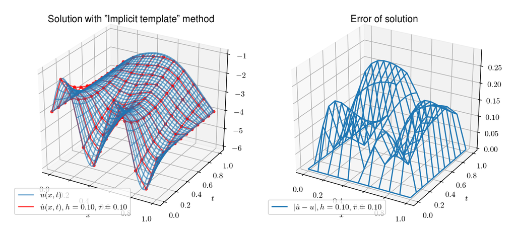

```python
fig3 = plot_solution(uu_impl, xx, tt, u_true, 'Implicit template')
```

#### C. Схема Кранка-Николсон

Шаблон:

Уравнение для значений слоя на следующем узле (вновь неявная схема, вновь СЛАУ, вновь прогонка):

$$\begin{align} u_0^{k+1} &= \mu_1^{k+1},\\ \frac{\gamma}{2}u_{i-1}^{k+1} - (1+\gamma)u_i^{k+1} + \frac{\gamma}{2}u_{i+1}^{k+1} &= -\frac{\gamma}{2}u_{i-1}^k -(1-\gamma)u_i^k - \frac{\gamma}{2}u_{i+1}^k - \frac{\tau}{2}(f_i^k + f_i^{k+1}), i\in\{1,...,n-1\},\\ u_n^{k+1} &= \mu_2^{k+1}.\end{align} $$

Схема имеет (в предположении 4-кратной непрерывной дифференцируемости решения по $x$ и трёхкратной по $\tau$) порядок аппроксимации $O(h^2+\tau^2)$ и является абсолютно устойчивой.

А для нашего примера:

$$ u_0^{k+1}=-3,\\ \frac{5}{4\pi^2} u_{i-1}^{k+1} - (1+\frac{5}{2\pi^2})u_i^{k+1} + \frac{5}{4\pi^2} u_{i+1}^{k+1} = -\frac{5}{4\pi^2} u_{i-1}^k - (1-\frac{5}{2\pi^2})u_i^k - -\frac{5}{4\pi^2} u_{i+1}^k - 0,15 \sin{\pi x_i} (\sin{2t_k}+\sin{2t_{k+1}}),\text{ }i\in\{1, ..., 9\},\\ u_{10}^{k+1}=-4.$$

```python
uu_cn = uu.copy()

# матрица системы в виде, пригодном для передачи параметром во
# встроенную функцию `solve_baned`, решающую СЛАУ методом прогонки
M = np.repeat(array([[gamma/2], [-(1+gamma)], [gamma/2]]), n-1, axis=1)
M[0, 0] = 0; M[-1, -1] = 0

for k in range(m):
    uk = uu_cn[k]
    rhs = -(gamma/2*uk[:-2] + (1-gamma)*uk[1:-1] + gamma/2*uk[2:] + tau/2*(ff[k, 1:-1] + ff[k+1, 1:-1]))
    rhs[0]  -= gamma * mu1(t[k+1]) / 2
    rhs[-1] -= gamma * mu2(t[k+1]) / 2
    uu_cn[k+1, 1:-1] = solve_banded((1, 1), M, rhs)

#uu_cn[::-1]
```

Максимальная погрешность аппроксимации на каждом временном слое:

```python
Series(np.max(np.abs(uu_cn - u_true(xx, tt)), axis=1), index=t)
```

```
0.0    8.881784e-16
0.1    6.063052e-02
0.2    8.349905e-02
0.3    8.644074e-02
0.4    7.979887e-02
0.5    6.937056e-02
0.6    5.824011e-02
0.7    4.790897e-02
0.8    3.898377e-02
0.9    3.158893e-02
1.0    2.560912e-02
dtype: float64
```

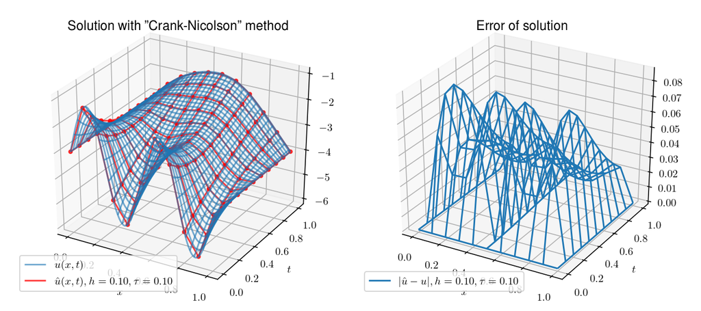

```python
fig4 = plot_solution(uu_cn, xx, tt, u_true, 'Crank-Nicolson')
```

### Сравнение результатов и выводы

Погрешность аппроксимации явной схемы:

```python
print("Среднеквадратичная: %.4f, равномерная: %.4f" %
      (np.linalg.norm(uu_expl - u_true(xx, tt)),
       np.max(np.abs(uu_expl - u_true(xx, tt)))))
```

```
Среднеквадратичная: 0.7550, равномерная: 0.1456
```

Погрешность аппроксимации неявной схемы:

```python
print("Среднеквадратичная: %.4f, равномерная: %.4f" %
      (np.linalg.norm(uu_impl - u_true(xx, tt)),
       np.max(np.abs(uu_impl - u_true(xx, tt)))))
```

```
Среднеквадратичная: 1.3716, равномерная: 0.2912
```

Погрешность аппроксимации схемы Кранка-Николсон:

```python
print("Среднеквадратичная: %.4f, равномерная: %.4f" %
      (np.linalg.norm(uu_cn - u_true(xx, tt)),
       np.max(np.abs(uu_cn - u_true(xx, tt)))))
```

```
Среднеквадратичная: 0.4454, равномерная: 0.0864
```

Как видим, в обеих нормах наилучшее приближение получается при использовании Схемы Кранка-Николсон, что обеспечивается вторым порядком аппроксимации не только по $h$, но и по $\tau$. Все три схемы заполняют следующий слой за линейное время, однако в явной схеме количество арифметических операций несколько меньше.